# 5. Linear Mixed-Effects Model

Accounting for block variation in an agricultural experiment

Author

Gustavo Roa

# Linear Mixed-Effects Models

Agricultural experiments often use blocks to account for variation across the field. A **linear mixed-effects model (LMM)** allows us to include treatment effects as fixed effects and block effects as random effects.

In this example, we will ask:

> **Does grain yield differ among sulfur rates after accounting for variation among blocks?**

The model is:

$$Y_{ij} = \mu + \tau_i + b_j + \varepsilon_{ij}$$

where:

- $Y_{ij}$ is the observed grain yield.
- $\mu$ is the overall mean.
- $\tau_i$ is the fixed effect of sulfur rate.
- $b_j$ is the random effect of block.
- $\varepsilon_{ij}$ is the residual error.

# Fixed and random effects

A **fixed effect** is a factor whose specific levels are of scientific interest.

In this example:

- **Sulfur rate** is a fixed effect because we want to compare the tested rates.
- **Block** is a random effect because we want to account for variation among blocks.

The choice of fixed or random effects depends on the research question and experimental design. For example, location or year could be treated differently in another study.

# Load the required packages

```r
# Import Excel files
library(readxl)

# Select and manipulate variables
library(dplyr)

# Create graphs
library(ggplot2)

# Fit linear mixed-effects models
library(lme4)

# Obtain Kenward-Roger tests
library(lmerTest)
library(pbkrtest)

# Estimate marginal means
library(emmeans)

# Create compact letter displays
library(multcomp)
library(multcompView)
```

# Load the data

We will use the same dataset used in the previous sections.

```r
# Import the workshop dataset
AllData <- read_excel(
  "Data_example.xlsx",
  sheet = "data"
)

# Check the structure of the dataset
str(AllData)
```

```
tibble [20 × 11] (S3: tbl_df/tbl/data.frame)
 $ year             : num [1:20] 2022 2022 2022 2022 2022 ...
 $ location         : chr [1:20] "Ashland" "Ashland" "Ashland" "Ashland" ...
 $ block            : num [1:20] 1 1 1 1 1 2 2 2 2 2 ...
 $ S_rate_kg_ha     : num [1:20] 34 11 45 22 0 0 34 22 11 45 ...
 $ grain_yield_Mg_ha: num [1:20] 9.04 10.66 11.25 10.06 7.75 ...
 $ biomass_V6_Mg_ha : num [1:20] 0.39 0.46 0.48 0.38 0.69 0.35 0.49 0.75 0.68 0.59 ...
 $ biomass_R1_Mg_ha : num [1:20] 7.82 8.52 7.6 7.47 10.3 ...
 $ S_conc_V6_pct    : num [1:20] 0.28 0.24 0.29 0.25 0.23 0.25 0.25 0.24 0.24 0.25 ...
 $ N_conc_V6_pct    : num [1:20] 3.86 3.65 3.78 3.67 3.74 3.93 3.8 3.68 3.87 3.66 ...
 $ S_conc_R1_pct    : num [1:20] 0.15 0.13 0.14 0.12 0.13 0.16 0.13 0.13 0.11 0.14 ...
 $ N_conc_R1_pct    : num [1:20] 1.7 1.57 1.7 1.38 1.59 1.81 1.62 1.6 1.41 1.63 ...
```

# Prepare the variables

Sulfur rate is converted to a factor because we want to compare the specific rates used in the experiment.

Block is converted to a factor because it identifies the experimental blocks.

```r
# Convert sulfur rate to a treatment factor
AllData$S_rate_kg_ha <- factor(AllData$S_rate_kg_ha)

# Convert block to a grouping factor
AllData$block <- factor(AllData$block)
```

# Fit the mixed model

We can fit the model using `lmer()`.

The model is:

```r
grain_yield_Mg_ha ~ S_rate_kg_ha + (1 | block)
```

Here:

- `grain_yield_Mg_ha` is the response variable.
- `S_rate_kg_ha` is the fixed effect.
- `(1 | block)` specifies block as a random effect.

```r
# Fit the linear mixed-effects model
model <- lmer(
  grain_yield_Mg_ha ~ S_rate_kg_ha + (1 | block),
  data = AllData,
  REML = TRUE
)

# Display the model summary
summary(model)
```

```
Linear mixed model fit by REML. t-tests use Satterthwaite's method [
lmerModLmerTest]
Formula: grain_yield_Mg_ha ~ S_rate_kg_ha + (1 | block)
   Data: AllData

REML criterion at convergence: 59.4

Scaled residuals:
     Min       1Q   Median       3Q      Max
-1.89446 -0.44360  0.05813  0.49126  1.57261

Random effects:
 Groups   Name        Variance Std.Dev.
 block    (Intercept) 0.2886   0.5372
 Residual             1.7181   1.3107
Number of obs: 20, groups:  block, 4

Fixed effects:
               Estimate Std. Error      df t value Pr(>|t|)
(Intercept)      8.1222     0.7083 13.8537  11.467 1.87e-08 ***
S_rate_kg_ha11   2.4177     0.9268 12.0000   2.609  0.02286 *
S_rate_kg_ha22   2.8710     0.9268 12.0000   3.098  0.00923 **
S_rate_kg_ha34   3.4204     0.9268 12.0000   3.690  0.00309 **
S_rate_kg_ha45   3.3106     0.9268 12.0000   3.572  0.00384 **
---
Signif. codes:  0 '***' 0.001 '**' 0.01 '*' 0.05 '.' 0.1 ' ' 1

Correlation of Fixed Effects:
            (Intr) S___11 S___22 S___34
S_rt_kg_h11 -0.654
S_rt_kg_h22 -0.654  0.500
S_rt_kg_h34 -0.654  0.500  0.500
S_rt_kg_h45 -0.654  0.500  0.500  0.500
```

# Test the sulfur effect

For mixed models, the denominator degrees of freedom need to be estimated.

The **Kenward-Roger (KR) method** provides an adjustment for these degrees of freedom when testing fixed effects.

```r
# Test the fixed effect using Kenward-Roger degrees of freedom
anova(
  model,
  ddf = "Kenward-Roger"
)
```

```
Type III Analysis of Variance Table with Kenward-Roger's method
             Sum Sq Mean Sq NumDF DenDF F value Pr(>F)
S_rate_kg_ha  31.41  7.8526     4    12  4.5706 0.0179 *
---
Signif. codes:  0 '***' 0.001 '**' 0.01 '*' 0.05 '.' 0.1 ' ' 1
```

The ANOVA table includes:

- **NumDF:** numerator degrees of freedom.
- **DenDF:** denominator degrees of freedom.
- **F value:** test statistic.
- **Pr(>F):** P-value for the sulfur effect.

The main question is:

> **Is there evidence that grain yield differs among sulfur rates after accounting for block variation?**

# Estimated marginal means

After testing the treatment effect, we can estimate the mean grain yield for each sulfur rate.

The `emmeans()` function calculates **estimated marginal means** from the fitted model.

```r
# Estimate marginal means using Kenward-Roger degrees of freedom
means <- emmeans(
  model,
  ~ S_rate_kg_ha,
  lmer.df = "kenward-roger"
)

# Display the estimated means
means
```

```
 S_rate_kg_ha emmean    SE   df lower.CL upper.CL
 0              8.12 0.708 13.8     6.60     9.64
 11            10.54 0.708 13.8     9.02    12.06
 22            10.99 0.708 13.8     9.47    12.51
 34            11.54 0.708 13.8    10.02    13.06
 45            11.43 0.708 13.8     9.91    12.95

Degrees-of-freedom method: kenward-roger
Confidence level used: 0.95
```

# Mean separation

When a treatment effect is of interest, we may want to compare individual treatment means.

There are several methods for multiple comparisons, including:

- Tukey
- Sidak
- Bonferroni
- Dunnett
- Fisher’s LSD

The appropriate method depends on the comparisons planned and the research question.

```r
# Create compact letter display
results <- cld(
  means,
  Letters = letters,
  lmer.df = "kenward-roger",
  sort = FALSE
) %>%
  as.data.frame() %>%
  mutate(
    letter = trimws(.group)
  )

# Display the treatment means and letters
results
```

```
  S_rate_kg_ha    emmean       SE       df  lower.CL  upper.CL .group letter
1            0  8.122215 0.708285 13.85368  6.601588  9.642842     a       a
2           11 10.539897 0.708285 13.85368  9.019270 12.060523     ab     ab
3           22 10.993232 0.708285 13.85368  9.472605 12.513859     ab     ab
4           34 11.542614 0.708285 13.85368 10.021987 13.063241      b      b
5           45 11.432849 0.708285 13.85368  9.912222 12.953476      b      b
```

The `letter` column summarizes the pairwise comparisons.

Treatments that share a letter are not significantly different according to the selected comparison procedure.

# Plot the estimated means

We can visualize the estimated means, confidence intervals, and letter groups.

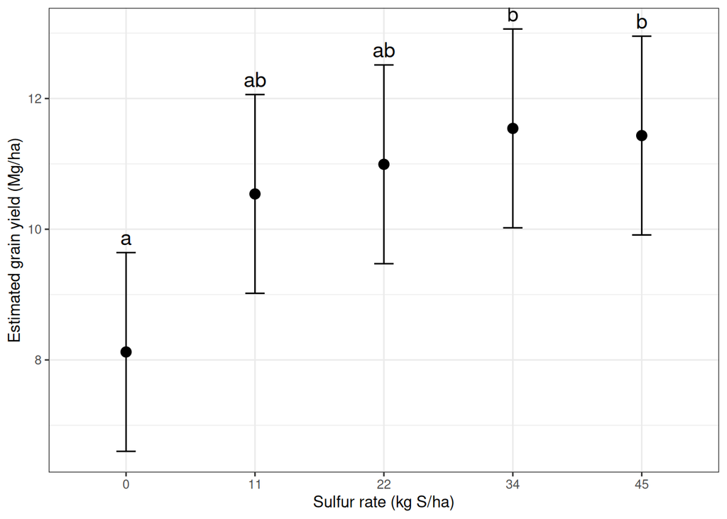

The figure shows:

- Estimated grain yield for each sulfur rate.
- 95% confidence intervals.
- Statistical groupings from the pairwise comparisons.

# Model assumptions

The main assumptions are:

- Observations are independent according to the experimental design.
- Residuals are approximately normally distributed.
- Residual variance is reasonably constant.

A simple residual plot can help identify obvious problems.

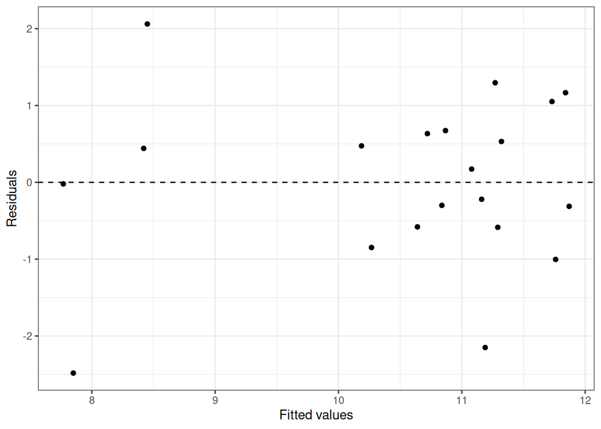

We are looking for residuals that are reasonably scattered around zero without strong patterns.

# Why use the mixed model?

The model:

```r
grain_yield_Mg_ha ~ S_rate_kg_ha + (1 | block)
```

accounts for two main sources of variation:

- **Sulfur rate:** the fixed effect we want to study.
- **Block:** variation associated with the experimental layout.

This allows the treatment comparison to account for the blocked design.

# Key takeaways

- A mixed model includes fixed and random effects.
- Sulfur rate is a fixed effect because we want to compare the tested rates.
- Block is a random effect because it accounts for variation among blocks.
- `(1 | block)` specifies a random intercept for block.
- `lmer()` fits the mixed model.
- The Kenward-Roger method provides adjusted degrees of freedom for testing fixed effects.
- `emmeans()` estimates treatment means from the fitted model.
- Multiple-comparison methods can be used to compare treatment means.
- `cld()` summarizes pairwise comparisons using letters.
- Residual diagnostics help evaluate model assumptions.
- The experimental design should guide the model structure.

> **The statistical model should reflect the experimental design. In a blocked agricultural experiment, block variation can be incorporated as a random effect.**